# Project: Classification - Hotel Booking Cancellation Prediction

## Preparing data for modeling

- Models cannot take non-numeric inputs. So, we will first create dummy variables for all the categorical variables.
- We will then split the data into train and test sets.

#### Question 3:

- **Drop the target variable from the original data and store it in a separate dataframe `X` (1 Mark)**
- **Store the target variable in a separate series `Y` (1 Mark)**

```python
#Remove the blanks and complete the below code
Y=data.booking_status
X=data.drop(columns=['booking_status'])
```

```python
#Creating dummy variables
#drop_first=True is used to avoid redundant variables
X = pd.get_dummies(X, drop_first=True)
```

```python
#Splitting the data into train and test sets
X_train,X_test,y_train,y_test=train_test_split(X, Y, test_size=0.30, random_state=1)
print(X_train.shape)
print(X_test.shape)
```

```
(25392, 27)
(10883, 27)
```

## Building Classification Models

**Before training the model, let's choose the appropriate model evaluation criterion as per the problem on hand.**

### Model evaluation criterion

#### Model can make wrong predictions as:

1. Predicting a customer will not cancel their booking but in reality, the customer will cancel their booking.
2. Predicting a customer will cancel their booking but in reality, the customer will not cancel their booking.

#### Which case is more important?

- Both the cases are important as:
- If we predict that a booking will not be canceled and the booking gets canceled then the hotel will lose resources and will have to bear additional costs of unsold rooms. The hotel might also have to bear an additional cost of advertising the room again on different distribution channels.
- If we predict that a booking will get canceled and the booking doesn't get canceled the hotel might not be able to provide satisfactory services to the customer by assuming that this booking will be canceled. This might damage the brand equity.

#### How to reduce the losses?

- Hotel would want `F1 Score` to be maximized, greater the F1 score higher are the chances of minimizing False Negatives and False Positives.

**Also, let's create a function to calculate and print the classification report and confusion matrix so that we don't have to rewrite the same code repeatedly for each model.**

```python
#function to print classification report and get confusion matrix in a proper format

def metrics_score(actual, predicted):
    print(classification_report(actual, predicted))
    cm = confusion_matrix(actual, predicted)
    plt.figure(figsize=(8,5))
    sns.heatmap(cm, annot=True,  fmt='.2f', xticklabels=['Not Canceled', 'Canceled'], yticklabels=['Not Canceled', 'Canceled'])
    plt.ylabel('Actual')
    plt.xlabel('Predicted')
    plt.show()
```

### Logistic Regression

#### Question 4: Fit the logistic regression model on the train dataset using random_state=1 (2 Marks)

```python
#define logistic regression model
log_reg= LogisticRegression() #Random state set while splitting the traininga nd test data

#fit the model
log_reg.fit(X_train, y_train)
```

```
LogisticRegression()
```

**Let's check the coefficient of each dependent variable in the data**

#### Question 5: Write your observations on the below coefficients obtained from the logistic regression model (3 Marks)

```python
pd.Series(log_reg.coef_[0], index=X_train.columns).sort_values(ascending=False)
```

```
market_segment_type_Online              0.622642
type_of_meal_plan_Not Selected          0.320868
no_of_weekend_nights                    0.180647
avg_price_per_room                      0.019642
lead_time                               0.015394
no_of_adults                            0.011339
no_of_week_nights                       0.006575
arrival_date                            0.001369
type_of_meal_plan_Meal Plan 3           0.000399
room_type_reserved_Room_Type 3          0.000340
arrival_year                           -0.001728
room_type_reserved_Room_Type 2         -0.004275
market_segment_type_Complementary      -0.008763
room_type_reserved_Room_Type 5         -0.011104
room_type_reserved_Room_Type 7         -0.017778
no_of_previous_cancellations           -0.024627
market_segment_type_Corporate          -0.031208
room_type_reserved_Room_Type 4         -0.032668
repeated_guest                         -0.043318
room_type_reserved_Room_Type 6         -0.045494
no_of_children                         -0.053729
arrival_month                          -0.057524
type_of_meal_plan_Meal Plan 2          -0.094090
required_car_parking_space             -0.138776
no_of_previous_bookings_not_canceled   -0.211896
market_segment_type_Offline            -0.596893
no_of_special_requests                 -1.547063
dtype: float64
```

**Observations:**_**** Features that positively affect on the cancellations are market_segment_type_Online type_of_meal_plan_Not Selected no_of_weekend_nights avg_prioce_per_room lead_time no_of_adultsno_of_week_nights arrival_date type_of_meal_plan_Meal Plan 3 room_type_reserved_Room_Type 3

Features that negatively affect the cancellations are arrival_year room_type_reserved_Room_Type 5 room_type_reserved_Room_Type 7 no_previous_cancellations market_segment_type_Corporate room_type_reserved_Room_Type 4 repeated_guest room_type_reserved_Room_Type 6 no_of_children arrival_month type_of_meal_plan_Meal Plan 2 required_car_parking_space no_of_previous_bookings_not_canceled market_segment_type_Offline no_of_special_requests

Need to convert this log of odds to real odds to help interpret this better.

#### Question 6: Write your interpretations of the odds calculated from the logistic regression model coefficients (3 Marks)

```python
odds = np.exp(log_reg.coef_[0]) #finding the odds

# adding the odds to a dataframe and sorting the values
pd.DataFrame(odds, X_train.columns, columns=['odds']).sort_values(by='odds', ascending=False)
```

|  | odds |
| --- | --- |
| market_segment_type_Online | 1.863845 |
| type_of_meal_plan_Not Selected | 1.378324 |
| no_of_weekend_nights | 1.197992 |
| avg_price_per_room | 1.019836 |
| lead_time | 1.015513 |
| no_of_adults | 1.011404 |
| no_of_week_nights | 1.006597 |
| arrival_date | 1.001370 |
| type_of_meal_plan_Meal Plan 3 | 1.000399 |
| room_type_reserved_Room_Type 3 | 1.000340 |
| arrival_year | 0.998274 |
| room_type_reserved_Room_Type 2 | 0.995734 |
| market_segment_type_Complementary | 0.991276 |
| room_type_reserved_Room_Type 5 | 0.988957 |
| room_type_reserved_Room_Type 7 | 0.982379 |
| no_of_previous_cancellations | 0.975674 |
| market_segment_type_Corporate | 0.969274 |
| room_type_reserved_Room_Type 4 | 0.967859 |
| repeated_guest | 0.957607 |
| room_type_reserved_Room_Type 6 | 0.955525 |
| no_of_children | 0.947689 |
| arrival_month | 0.944099 |
| type_of_meal_plan_Meal Plan 2 | 0.910201 |
| required_car_parking_space | 0.870423 |
| no_of_previous_bookings_not_canceled | 0.809049 |
| market_segment_type_Offline | 0.550520 |
| no_of_special_requests | 0.212872 |

**Now, let's check the performance of the model on the training set**

#### Question 7: Check the performance on the training data and write your observations from the classification report and confusion matrix for the training set (3 Marks)

```
              precision    recall  f1-score   support

           0       0.82      0.89      0.86     17029
           1       0.74      0.61      0.67      8363

    accuracy                           0.80     25392
   macro avg       0.78      0.75      0.76     25392
weighted avg       0.80      0.80      0.79     25392
```

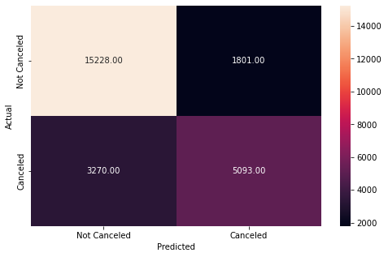

```python
# Checking performance on the training data
optimal_threshold=0.35
y_pred_train = log_reg.predict(X_train)
metrics_score(y_train, y_pred_train)
```

**Reading confusion matrix (clockwise):**

- **True Positive**: Predicting the customer will not cancel the booking and the customer does not cancel the booking
- **False Negative**: Predicting the customer will cancel the booking but the customer does not cancel the booking
- **True Negative**: Predicting the customer will cancel the booking and the customer cancels the booking
- **False Positive**: Predicting the customer will not cancel the booking but the customer cancels the booking

**Precision-Recall Curve for Logistic Regression**

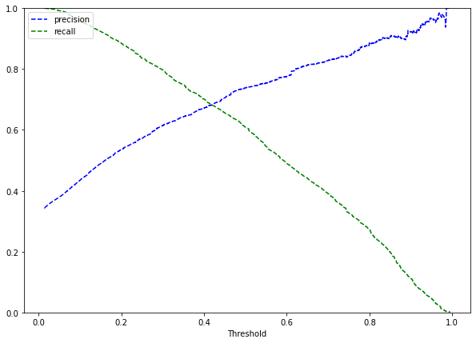

```python
y_scores=log_reg.predict_proba(X_train) #predict_proba gives the probability of each observation belonging to each class


precisions, recalls, thresholds = precision_recall_curve(y_train, y_scores[:,1])

#Plot values of precisions, recalls, and thresholds
plt.figure(figsize=(10,7))
plt.plot(thresholds, precisions[:-1], 'b--', label='precision')
plt.plot(thresholds, recalls[:-1], 'g--', label = 'recall')
plt.xlabel('Threshold')
plt.legend(loc='upper left')
plt.ylim([0,1])
plt.show()
```

**Observations:**

- We can see that **precision and recall are balanced for the threshold of about 0.4.**
- Let's try to calculate the exact threshold where precision and recall are equal.

```python
#calculating the exact threshold where precision and recall are equal.
for i in np.arange(len(thresholds)):
    if precisions[i]==recalls[i]:
        print(thresholds[i])
```

```
0.4180815097351187
```

- The threshold of 0.42 would give a balanced precision and recall.

#### Question 8: Compare the performance of the model on training and testing sets after changing the threshold (2 Marks)

```
              precision    recall  f1-score   support

           0       0.84      0.84      0.84     17029
           1       0.68      0.68      0.68      8363

    accuracy                           0.79     25392
   macro avg       0.76      0.76      0.76     25392
weighted avg       0.79      0.79      0.79     25392
```

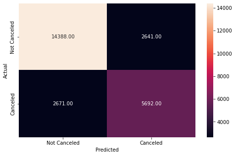

```python
optimal_threshold1 = 0.42
metrics_score(y_train, y_scores[:,1]>optimal_threshold1)
```

**Let's check the performance of the model on the test data**

```
              precision    recall  f1-score   support

           0       0.85      0.85      0.85      7361
           1       0.68      0.68      0.68      3522

    accuracy                           0.79     10883
   macro avg       0.77      0.77      0.77     10883
weighted avg       0.79      0.79      0.79     10883
```

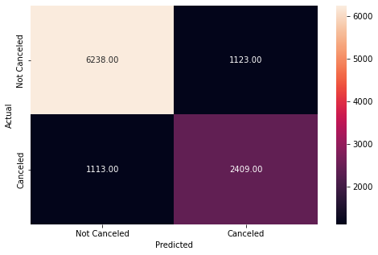

```python
#Checking performance on the testing data
y_pred_test = log_reg.predict_proba(X_test)
metrics_score(y_test, y_pred_test[:,1]>optimal_threshold1)
```

**Observations:**_**** With the optimal threshold value of 0.42, overall prediction accurancy has remained more or less at the same level ~0.80 but model is consistent across Training and test data.